# 5_Project1

Jaime Hernandez

April 30, 2019

## Introduction

It is now possible to collect a large amount of data about personal movement using activity monitoring devices such as a Fitbit, Nike Fuelband, or Jawbone Up. These type of devices are part of the “quantified self” movement - a group of enthusiasts who take measurements about themselves regularly to improve their health, to find patterns in their behavior, or because they are tech geeks. But these data remain under-utilized both because the raw data are hard to obtain and there is a lack of statistical methods and software for processing and interpreting the data.

This assignment makes use of data from a personal activity monitoring device. This device collects data at 5 minute intervals through out the day. The data consists of two months of data from an anonymous individual collected during the months of October and November, 2012 and include the number of steps taken in 5 minute intervals each day.

The data for this assignment can be downloaded from the course web site:

- Dataset: [Activity monitoring data](https://d396qusza40orc.cloudfront.net/repdata%2Fdata%2Factivity.zip)

## 1. Code for readubg in the dataset

```r
zipfile <- 'activity.zip'
unzip(zipfile, files = NULL, list = FALSE, overwrite = TRUE,
      junkpaths = FALSE, exdir = ".", unzip = "internal",
      setTimes = FALSE)

df <- read.csv("activity.csv")
df[is.na(df)] <- 0
```

## 2. Histogram of the total number of steps taken each day

```r
library(dplyr)
```

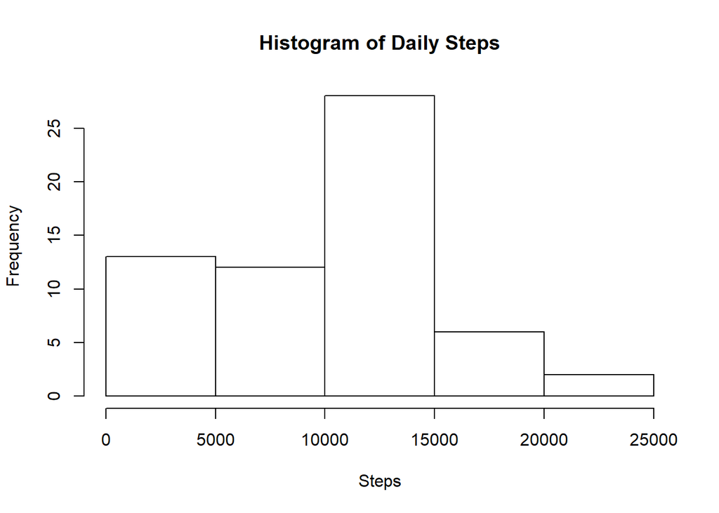

```r
hist_df <- df %>%
    group_by(date) %>%
    summarise(daily_steps = sum(steps))

hist(hist_df$daily_steps, main = "Histogram of Daily Steps", xlab = "Steps")
```

## 3. Mean and median number of steps taken each day

```r
mean(hist_df$daily_steps)
```

```
## [1] 9354.23
```

```r
median(hist_df$daily_steps)
```

```
## [1] 10395
```

## 4. Time series plot of the average number of steps taken

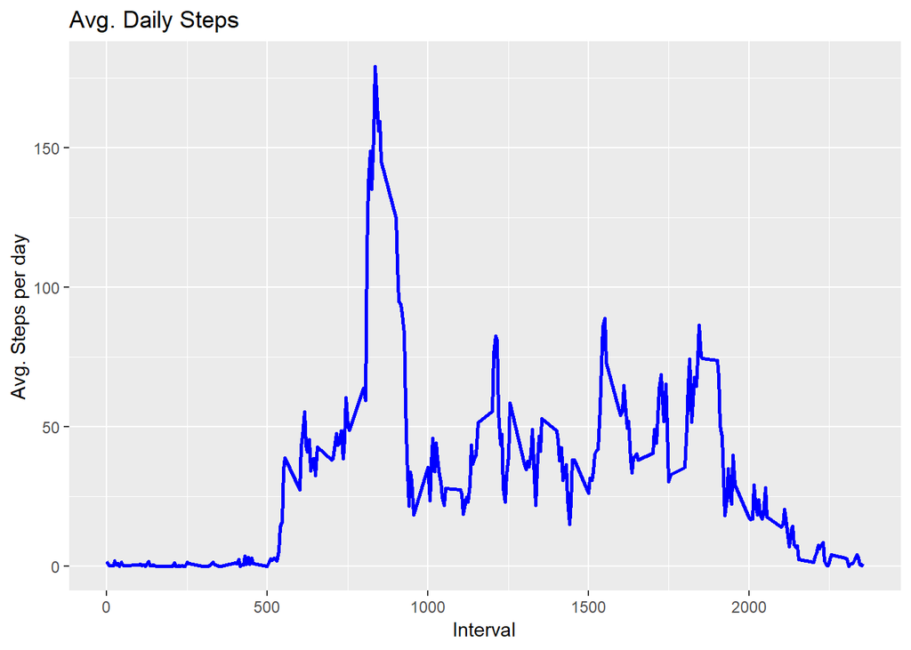

```r
library(ggplot2)
time_df <- df %>%
    group_by(interval) %>%
    summarise(avg_steps = mean(steps))



ggplot(time_df, aes(x = interval , y = avg_steps)) + geom_line(color="blue", size=1) + labs(title = "Avg. Daily Steps", x = "Interval", y = "Avg. Steps per day")
```

## 5. The 5-minute interval that, on average, contains the maximum number of steps

```r
max_int <- time_df %>%
    filter(avg_steps == max(time_df$avg_steps))
max_int
```

```
## # A tibble: 1 x 2
##   interval avg_steps
##      <int>     <dbl>
## 1      835      179.
```

## 6. Code to describe and show a strategy for imputing missing data

Calculate the average steps by interval

```r
df <- df %>% group_by(interval) %>%
    mutate(avg_int = mean(steps))
```

Replace the missing values with the average values calculated above

```r
df_missing_data <- read.csv("activity.csv")
df_missing_data$avg_int <- df$avg_int
df_missing_data$steps_final <- ifelse(is.na(df_missing_data$steps), df_missing_data$avg_int, df_missing_data$steps)
```

## 7. Histogram of the total number of steps taken each day after missing values are imputed

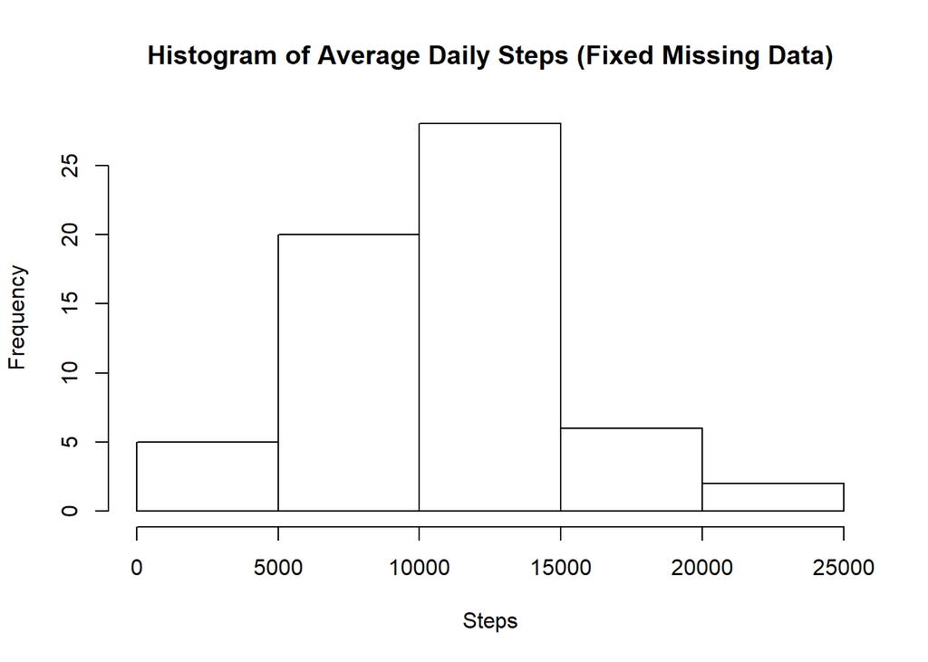

```r
hist_2 <- df_missing_data %>%
    group_by(date) %>%
    summarise(avg_steps = sum(steps_final))

hist(hist_2$avg_steps, main = "Histogram of Average Daily Steps (Fixed Missing Data)", xlab = "Steps")
```

## 8. Panel plot comparing the average number of steps taken per 5-minute interval across weekdays and weekends

Figure out what data points were taken in weekdays and what data points were taken in weekends

```r
df_missing_data$day <- weekdays(as.Date(df_missing_data$date))
df_missing_data$wday_wknd <- ifelse(df_missing_data$day == 'Saturday' | df_missing_data$day == 'Sunday', 'weekend','weekday')
```

Figure out the average number steps taken per interval for weekdays and weekends separately

```r
df_wday_wknd <- df_missing_data %>%
    group_by(wday_wknd, interval) %>%
    summarise(daily_steps = mean(steps_final))
```

Pannel Plot

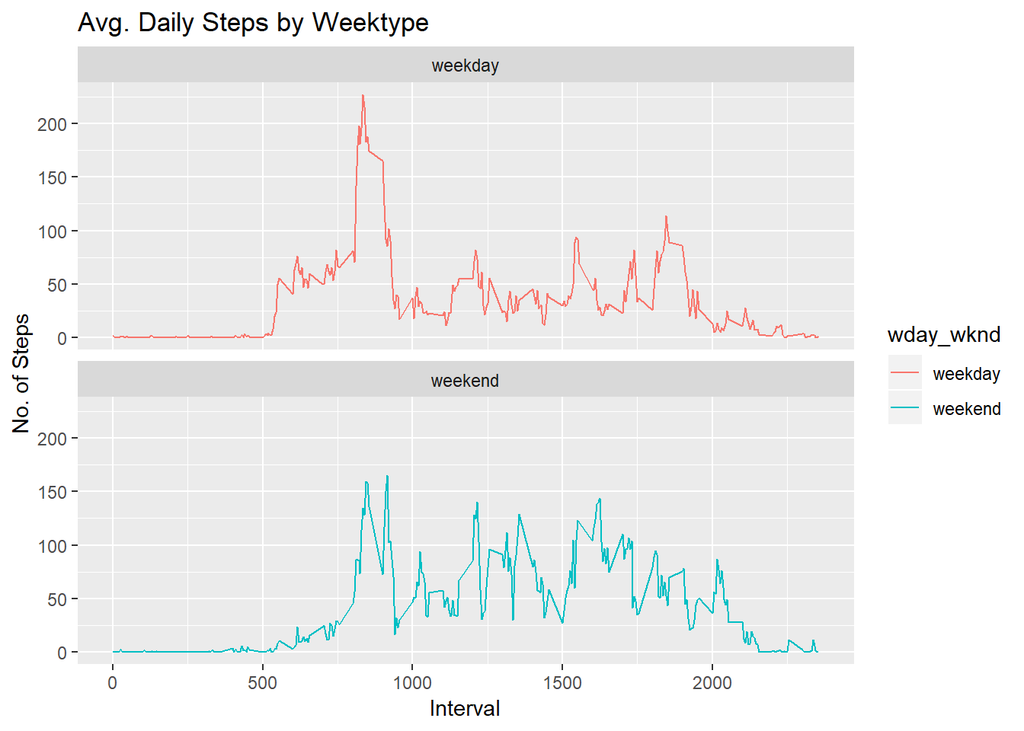

```r
ggplot(df_wday_wknd , aes(x = interval , y = daily_steps, color=`wday_wknd`)) + geom_line() + labs(title = "Avg. Daily Steps by Weektype", x = "Interval", y = "No. of Steps") + facet_wrap(~`wday_wknd` , ncol = 1, nrow=2)
```

## 9. All of the R code needed to reproduce the results (numbers, plots, etc.) in the report

All code is above.